# Description

## Background and Context

AllLife Bank is a US bank that has a growing customer base. The majority of these customers are liability customers (depositors) with varying sizes of deposits. The number of customers who are also borrowers (asset customers) is quite small, and the bank is interested in expanding this base rapidly to bring in more loan business and in the process, earn more through the interest on loans. In particular, the management wants to explore ways of converting its liability customers to personal loan customers (while retaining them as depositors).

A campaign that the bank ran last year for liability customers showed a healthy conversion rate of over 9% success. This has encouraged the retail marketing department to devise campaigns with better target marketing to increase the success ratio.

You as a Data scientist at AllLife bank have to build a model that will help the marketing department to identify the potential customers who have a higher probability of purchasing the loan.

## Objective

1. To predict whether a liability customer will buy a personal loan or not.
2. Which variables are most significant.
3. Which segment of customers should be targeted more.

## Data Dictionary

- ID: Customer ID
- Age: Customer’s age in completed years
- Experience: #years of professional experience
- Income: Annual income of the customer (in thousand dollars)
- ZIP Code: Home Address ZIP code.
- Family: the Family size of the customer
- CCAvg: Average spending on credit cards per month (in thousand dollars)
- Education: Education Level. 1: Undergrad; 2: Graduate;3: Advanced/Professional
- Mortgage: Value of house mortgage if any. (in thousand dollars)
- Personal_Loan: Did this customer accept the personal loan offered in the last campaign?
- Securities_Account: Does the customer have securities account with the bank?
- CD_Account: Does the customer have a certificate of deposit (CD) account with the bank?
- Online: Do customers use internet banking facilities?
- CreditCard: Does the customer use a credit card issued by any other Bank (excluding All life Bank)?

```python
# this will help in making the Python code more structured automatically (good coding practice)
%load_ext nb_black

# Library to suppress warnings or deprecation notes
import warnings

warnings.filterwarnings("ignore")

# Libraries to help with reading and manipulating data

import pandas as pd
import numpy as np

# Library to split data
from sklearn.model_selection import train_test_split

# libaries to help with data visualization
import matplotlib.pyplot as plt
import seaborn as sns

# Removes the limit for the number of displayed columns
pd.set_option("display.max_columns", None)
# Sets the limit for the number of displayed rows
pd.set_option("display.max_rows", 200)

# Libraries to build decision tree classifier
from sklearn.tree import DecisionTreeClassifier
from sklearn import tree


# To build model for prediction

from sklearn.linear_model import LogisticRegression

# To tune different models
from sklearn.model_selection import GridSearchCV

# To get diferent metric scores
from sklearn.metrics import (
    f1_score,
    accuracy_score,
    recall_score,
    precision_score,
    confusion_matrix,
    plot_confusion_matrix,
    make_scorer,
    roc_auc_score,
    precision_recall_curve,
    roc_curve,
)
```

### Read the dataset

```python
loan_campaign = pd.read_csv("Loan_Modelling.csv")
```

```python
# copying data to another varaible to avoid any changes to original data
data = loan_campaign.copy()
```

### View the first and last 5 rows of the dataset.

```python
data.head()
```

|  | ID | Age | Experience | Income | ZIPCode | Family | CCAvg | Education | Mortgage | Personal_Loan | Securities_Account | CD_Account | Online | CreditCard |
| --- | --- | --- | --- | --- | --- | --- | --- | --- | --- | --- | --- | --- | --- | --- |
| 0 | 1 | 25 | 1 | 49 | 91107 | 4 | 1.6 | 1 | 0 | 0 | 1 | 0 | 0 | 0 |
| 1 | 2 | 45 | 19 | 34 | 90089 | 3 | 1.5 | 1 | 0 | 0 | 1 | 0 | 0 | 0 |
| 2 | 3 | 39 | 15 | 11 | 94720 | 1 | 1.0 | 1 | 0 | 0 | 0 | 0 | 0 | 0 |
| 3 | 4 | 35 | 9 | 100 | 94112 | 1 | 2.7 | 2 | 0 | 0 | 0 | 0 | 0 | 0 |
| 4 | 5 | 35 | 8 | 45 | 91330 | 4 | 1.0 | 2 | 0 | 0 | 0 | 0 | 0 | 1 |

```python
data.tail()
```

|  | ID | Age | Experience | Income | ZIPCode | Family | CCAvg | Education | Mortgage | Personal_Loan | Securities_Account | CD_Account | Online | CreditCard |
| --- | --- | --- | --- | --- | --- | --- | --- | --- | --- | --- | --- | --- | --- | --- |
| 4995 | 4996 | 29 | 3 | 40 | 92697 | 1 | 1.9 | 3 | 0 | 0 | 0 | 0 | 1 | 0 |
| 4996 | 4997 | 30 | 4 | 15 | 92037 | 4 | 0.4 | 1 | 85 | 0 | 0 | 0 | 1 | 0 |
| 4997 | 4998 | 63 | 39 | 24 | 93023 | 2 | 0.3 | 3 | 0 | 0 | 0 | 0 | 0 | 0 |
| 4998 | 4999 | 65 | 40 | 49 | 90034 | 3 | 0.5 | 2 | 0 | 0 | 0 | 0 | 1 | 0 |
| 4999 | 5000 | 28 | 4 | 83 | 92612 | 3 | 0.8 | 1 | 0 | 0 | 0 | 0 | 1 | 1 |

- Zip codes contains features that can be preprocessed
- Education is a categorical variable and not numerical
- Personal Loan is the target variable

### Understand the shape of the dataset.

```python
data.shape
```

```
(5000, 14)
```

- Dataset has 5000 rows and 14 columns

### Let's check the duplicate data. And if any, we should remove it.

```python
data[data.duplicated()].count()
```

```
ID                    0
Age                   0
Experience            0
Income                0
ZIPCode               0
Family                0
CCAvg                 0
Education             0
Mortgage              0
Personal_Loan         0
Securities_Account    0
CD_Account            0
Online                0
CreditCard            0
dtype: int64
```

- There are no duplicate values in the dataset

### Check the data types of the columns for the dataset.

```python
data.info()
```

```
<class 'pandas.core.frame.DataFrame'>
RangeIndex: 5000 entries, 0 to 4999
Data columns (total 14 columns):
 #   Column              Non-Null Count  Dtype
---  ------              --------------  -----
 0   ID                  5000 non-null   int64
 1   Age                 5000 non-null   int64
 2   Experience          5000 non-null   int64
 3   Income              5000 non-null   int64
 4   ZIPCode             5000 non-null   int64
 5   Family              5000 non-null   int64
 6   CCAvg               5000 non-null   float64
 7   Education           5000 non-null   int64
 8   Mortgage            5000 non-null   int64
 9   Personal_Loan       5000 non-null   int64
 10  Securities_Account  5000 non-null   int64
 11  CD_Account          5000 non-null   int64
 12  Online              5000 non-null   int64
 13  CreditCard          5000 non-null   int64
dtypes: float64(1), int64(13)
memory usage: 547.0 KB
```

### Insights:

- Most of the data-types are **int64**.
- Only **`CCAvg`** was in **float64**.

### Think about it:

  `True == 1`

  `False == 0`

  This means that an algorithm running in Python should work without conversion.

### Check for missing values

```python
data.isnull().sum()
```

```
ID                    0
Age                   0
Experience            0
Income                0
ZIPCode               0
Family                0
CCAvg                 0
Education             0
Mortgage              0
Personal_Loan         0
Securities_Account    0
CD_Account            0
Online                0
CreditCard            0
dtype: int64
```

- There are no missing values in the data.

### Summary of the dataset

```python
data.describe().T
```

|  | count | mean | std | min | 25% | 50% | 75% | max |
| --- | --- | --- | --- | --- | --- | --- | --- | --- |
| ID | 5000.0 | 2500.500000 | 1443.520003 | 1.0 | 1250.75 | 2500.5 | 3750.25 | 5000.0 |
| Age | 5000.0 | 45.338400 | 11.463166 | 23.0 | 35.00 | 45.0 | 55.00 | 67.0 |
| Experience | 5000.0 | 20.104600 | 11.467954 | -3.0 | 10.00 | 20.0 | 30.00 | 43.0 |
| Income | 5000.0 | 73.774200 | 46.033729 | 8.0 | 39.00 | 64.0 | 98.00 | 224.0 |
| ZIPCode | 5000.0 | 93169.257000 | 1759.455086 | 90005.0 | 91911.00 | 93437.0 | 94608.00 | 96651.0 |
| Family | 5000.0 | 2.396400 | 1.147663 | 1.0 | 1.00 | 2.0 | 3.00 | 4.0 |
| CCAvg | 5000.0 | 1.937938 | 1.747659 | 0.0 | 0.70 | 1.5 | 2.50 | 10.0 |
| Education | 5000.0 | 1.881000 | 0.839869 | 1.0 | 1.00 | 2.0 | 3.00 | 3.0 |
| Mortgage | 5000.0 | 56.498800 | 101.713802 | 0.0 | 0.00 | 0.0 | 101.00 | 635.0 |
| Personal_Loan | 5000.0 | 0.096000 | 0.294621 | 0.0 | 0.00 | 0.0 | 0.00 | 1.0 |
| Securities_Account | 5000.0 | 0.104400 | 0.305809 | 0.0 | 0.00 | 0.0 | 0.00 | 1.0 |
| CD_Account | 5000.0 | 0.060400 | 0.238250 | 0.0 | 0.00 | 0.0 | 0.00 | 1.0 |
| Online | 5000.0 | 0.596800 | 0.490589 | 0.0 | 0.00 | 1.0 | 1.00 | 1.0 |
| CreditCard | 5000.0 | 0.294000 | 0.455637 | 0.0 | 0.00 | 0.0 | 1.00 | 1.0 |

- Mortgage value is highly skewed

### Univariate analysis

```python
def histogram_boxplot(data, feature, figsize=(15, 10), kde=False, bins=None):
    """
    Boxplot and histogram combined

    data: dataframe
    feature: dataframe column
    figsize: size of figure (default (15,10))
    kde: whether to show the density curve (default False)
    bins: number of bins for histogram (default None)
    """
    f2, (ax_box2, ax_hist2) = plt.subplots(
        nrows=2,  # Number of rows of the subplot grid= 2
        sharex=True,  # x-axis will be shared among all subplots
        gridspec_kw={"height_ratios": (0.25, 0.75)},
        figsize=figsize,
    )  # creating the 2 subplots
    sns.boxplot(
        data=data, x=feature, ax=ax_box2, showmeans=True, color="violet"
    )  # boxplot will be created and a star will indicate the mean value of the column
    sns.histplot(
        data=data, x=feature, kde=kde, ax=ax_hist2, bins=bins, palette="winter"
    ) if bins else sns.histplot(
        data=data, x=feature, kde=kde, ax=ax_hist2
    )  # For histogram
    ax_hist2.axvline(
        data[feature].mean(), color="green", linestyle="--"
    )  # Add mean to the histogram
    ax_hist2.axvline(
        data[feature].median(), color="black", linestyle="-"
    )  # Add median to the histogram
```

### Observations on Age

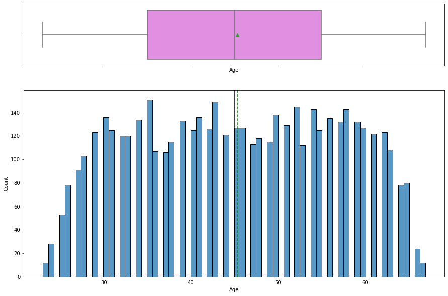

```python
histogram_boxplot(data, "Age", bins=70)
```

- The Age is normally skewed without ouliers

### Observations on Experience

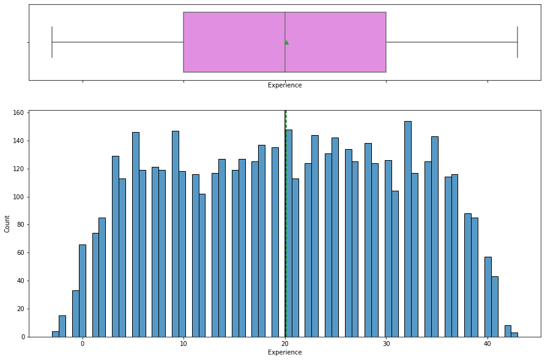

```python
histogram_boxplot(data, "Experience", bins=70)
```

- The Experience is normally skewed without ouliers

### Observations on Income

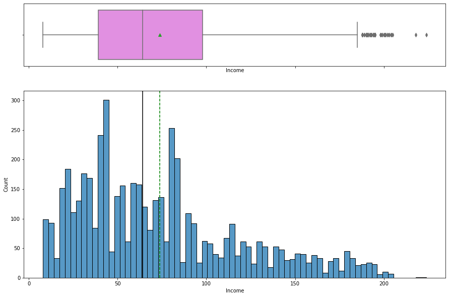

```python
histogram_boxplot(data, "Income", bins=70)
```

- The Income is right skewed with ouliers

### Observations on CCAvg

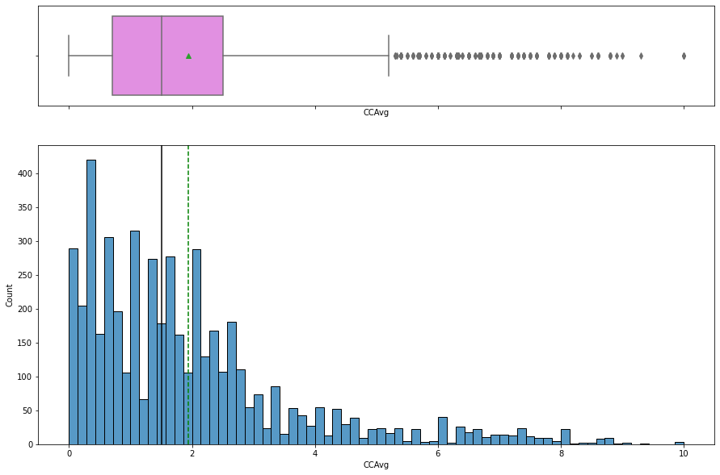

```python
histogram_boxplot(data, "CCAvg", bins=70)
```

### Observations on Mortgage

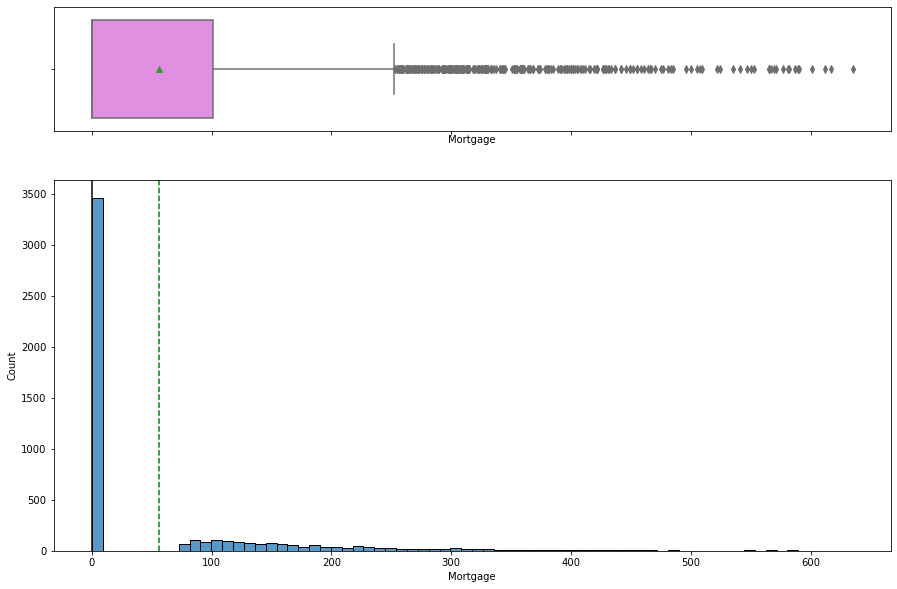

```python
histogram_boxplot(data, "Mortgage", bins=70)
```

- The Mortgage is highly skewed with ouliers

```python
# function to create labeled barplots


def labeled_barplot(data, feature, perc=False, n=None):
    """
    Barplot with percentage at the top

    data: dataframe
    feature: dataframe column
    perc: whether to display percentages instead of count (default is False)
    n: displays the top n category levels (default is None, i.e., display all levels)
    """

    total = len(data[feature])  # length of the column
    count = data[feature].nunique()
    if n is None:
        plt.figure(figsize=(count + 2, 6))
    else:
        plt.figure(figsize=(n + 2, 6))

    plt.xticks(rotation=90, fontsize=15)
    ax = sns.countplot(
        data=data,
        x=feature,
        palette="Paired",
        order=data[feature].value_counts().index[:n].sort_values(),
    )

    for p in ax.patches:
        if perc == True:
            label = "{:.1f}%".format(
                100 * p.get_height() / total
            )  # percentage of each class of the category
        else:
            label = p.get_height()  # count of each level of the category

        x = p.get_x() + p.get_width() / 2  # width of the plot
        y = p.get_height()  # height of the plot

        ax.annotate(
            label,
            (x, y),
            ha="center",
            va="center",
            size=12,
            xytext=(0, 5),
            textcoords="offset points",
        )  # annotate the percentage

    plt.show()  # show the plot
```

### Observations on Family

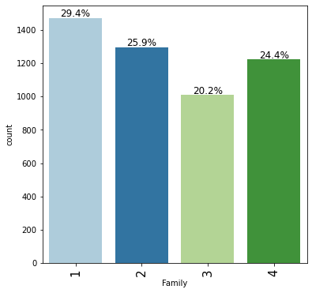

```python
labeled_barplot(data, "Family", perc=True)
```

- 29.4% of the customer base are of family size of 1 followed by Family size of 2 with 25.9%

### Observations on Education

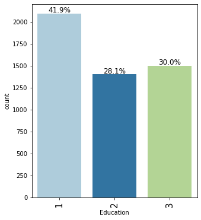

```python
labeled_barplot(data, "Education", perc=True)
```

- 41.9% of the customer base are Undergraduates followed by Advanced/Professional with 30.0%

### Observations on Family

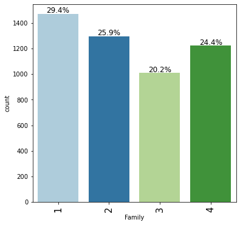

```python
labeled_barplot(data, "Family", perc=True)
```

- 29.4% of the customer base are of family size of 1 followed by Family size of 2 with 25.9%.

### Observations on Securities_Account

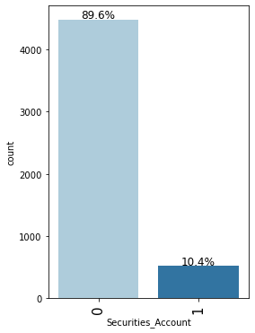

```python
labeled_barplot(data, "Securities_Account", perc=True)
```

- Most of the Customers do not have securities with the bank

### Observations on CD_Account

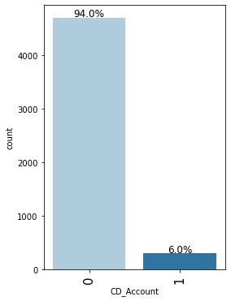

```python
labeled_barplot(data, "CD_Account", perc=True)
```

- Most of the customers do not have certiificate of Deposit Account

### Observations on Online

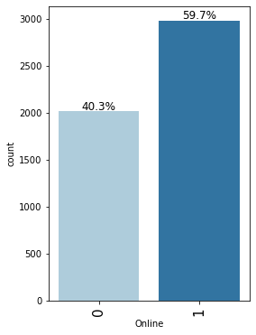

```python
labeled_barplot(data, "Online", perc=True)
```

- Most of the customers use the online Facilities

### Observations on CreditCard

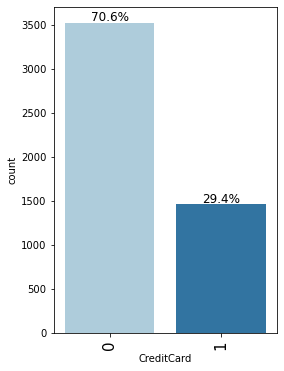

```python
labeled_barplot(data, "CreditCard", perc=True)
```

- Most of the customers do not use a credit card facility

### Observations on Personal_Loan

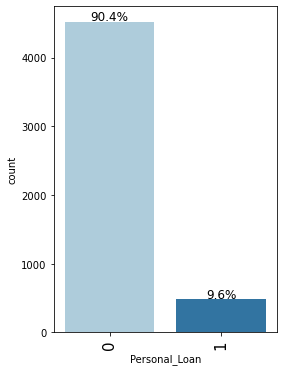

```python
labeled_barplot(data, "Personal_Loan", perc=True)
```

- Most of the customers did not accept a personal loan

### Observations on ZIPCode

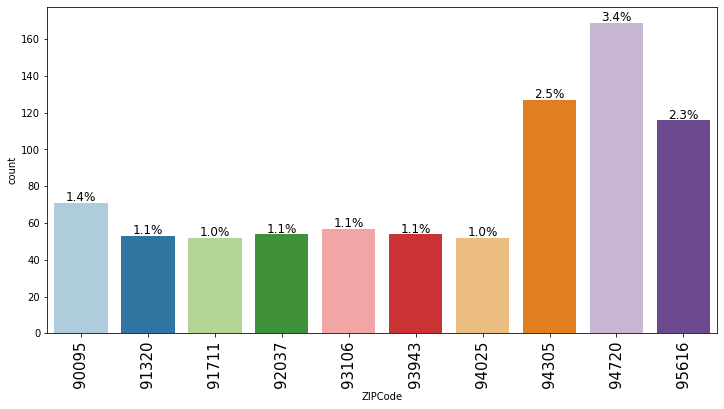

```python
labeled_barplot(data, "ZIPCode", perc=True, n=10)
```

- The Zip codes are not unique for each records

```python
# Value Counts for Zip Code
data.ZIPCode.value_counts()
```

```
94720    169
94305    127
95616    116
90095     71
93106     57
        ...
96145      1
94087      1
91024      1
93077      1
94598      1
Name: ZIPCode, Length: 467, dtype: int64
```

- There are 467 unique Zip Codes
- Features need to be exracted from the Zip Code

## Bivariate Analysis

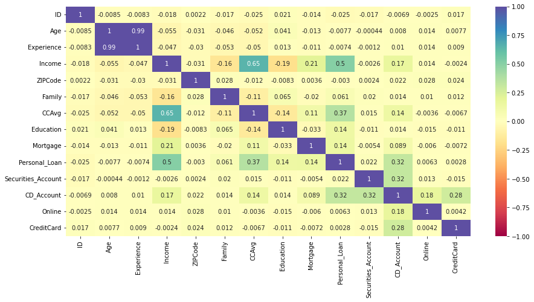

```python
plt.figure(figsize=(15, 7))
sns.heatmap(data.corr(), annot=True, vmin=-1, vmax=1, cmap="Spectral")
plt.show()
```

- Age and Experience are highly correlated and one needs to be dropped
- Personal loan is not hightly corelated with other variables. However, Income, CCAvg and CD_Account come Top.
- This will be further investigated
- CCAvg is highly correlated with income which is understandable

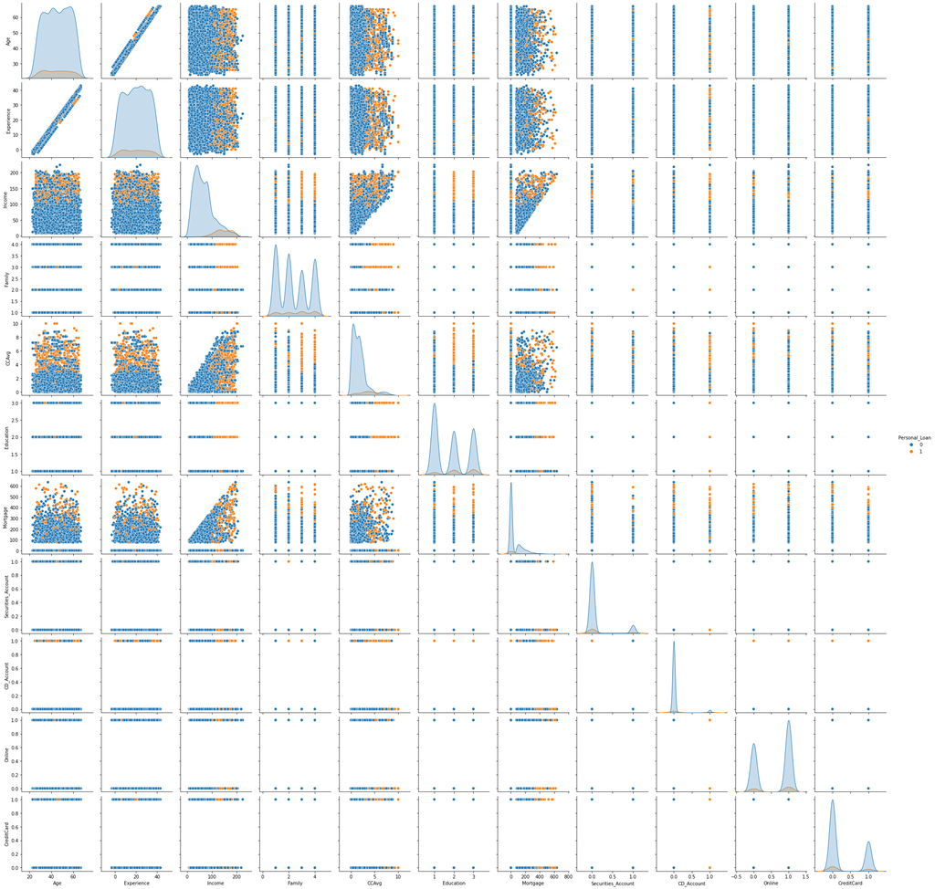

```python
sns.pairplot(data=data.drop(["ID", "ZIPCode"], axis=1), hue="Personal_Loan")
plt.show()
```

- We can see varying distributions in variables for Personal_Loan, we should investigate it further.

### Personal_Loan vs Income, CCAvg and CD_Account

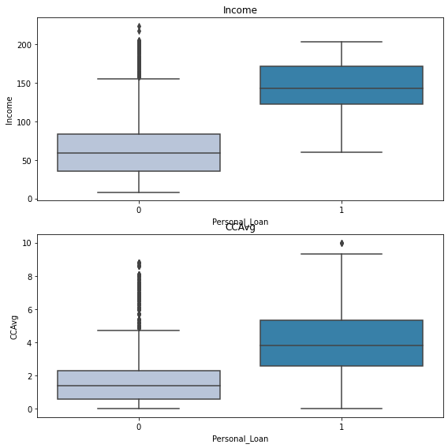

```python
cols = data[
    [
        "Income",
        "CCAvg"
    ]
].columns.tolist()
plt.figure(figsize=(8, 8))

for i, variable in enumerate(cols):
    plt.subplot(2, 1, i + 1)
    sns.boxplot(data["Personal_Loan"], data[variable], palette="PuBu")
    plt.tight_layout()
    plt.title(variable)
plt.show()
```

**It is difficult to make an interpretation from the graphs above let's visualize them by removing these outliers (for visualization not from orignal data) to get a better understanding**

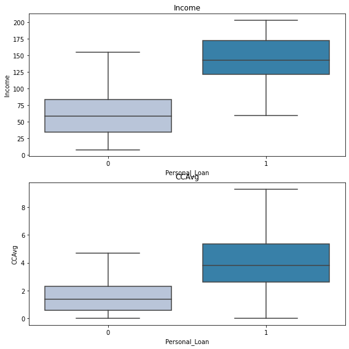

```python
cols = data[
    [
        "Income",
        "CCAvg"
    ]
].columns.tolist()
plt.figure(figsize=(8, 8))

for i, variable in enumerate(cols):
    plt.subplot(2, 1, i + 1)
    sns.boxplot(data["Personal_Loan"], data[variable], palette="PuBu", showfliers=False)
    plt.tight_layout()
    plt.title(variable)
plt.show()
```

- Customers with more Income and CCAvg are more likely to take personal loan

```python
# function to plot stacked bar chart


def stacked_barplot(data, predictor, target):
    """
    Print the category counts and plot a stacked bar chart

    data: dataframe
    predictor: independent variable
    target: target variable
    """
    count = data[predictor].nunique()
    sorter = data[target].value_counts().index[-1]
    tab1 = pd.crosstab(data[predictor], data[target], margins=True).sort_values(
        by=sorter, ascending=False
    )
    print(tab1)
    print("-" * 120)
    tab = pd.crosstab(data[predictor], data[target], normalize="index").sort_values(
        by=sorter, ascending=False
    )
    tab.plot(kind="bar", stacked=True, figsize=(count + 5, 6))
    plt.legend(
        loc="lower left", frameon=False,
    )
    plt.legend(loc="upper left", bbox_to_anchor=(1, 1))
    plt.show()
```

```
Personal_Loan     0    1   All
CD_Account
All            4520  480  5000
0              4358  340  4698
1               162  140   302
------------------------------------------------------------------------------------------------------------------------
```

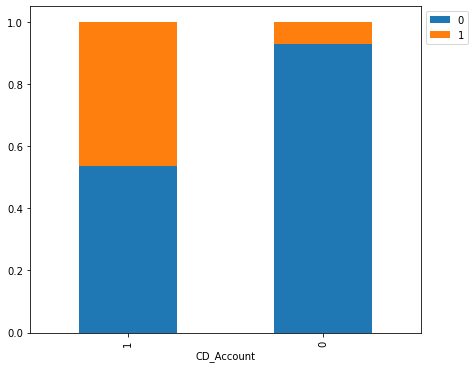

```python
stacked_barplot(data, "CD_Account", "Personal_Loan")
```

```
Personal_Loan     0    1   All
Education
All            4520  480  5000
3              1296  205  1501
2              1221  182  1403
1              2003   93  2096
------------------------------------------------------------------------------------------------------------------------
```

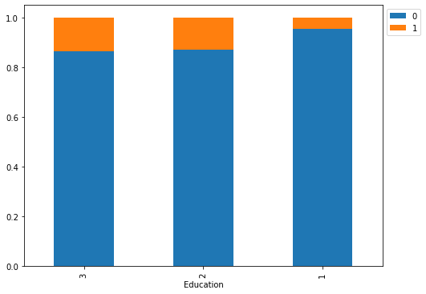

```python
stacked_barplot(data, "Education", "Personal_Loan")
```

- Advanced/Professionals have more tendency to take loans than other Education levels although they are not the highest
- This is similar to the graduates

```
Personal_Loan     0    1   All
Family
All            4520  480  5000
4              1088  134  1222
3               877  133  1010
1              1365  107  1472
2              1190  106  1296
------------------------------------------------------------------------------------------------------------------------
```

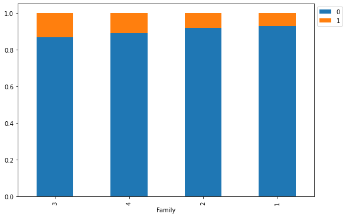

```python
stacked_barplot(data, "Family", "Personal_Loan")
```

- Larger sized Families have more tendency to accepet a Personal Loan as they would have more financial needs

### Summary of EDA

**Data Description:**

- There are no duplicate values in the dataset, which were dropped.
- There are no missing values in the data.
- Most of the data-types are **int64**.

## Data Preprocessing

Here, Further processing will be carried out on the Zip Code to Extract **Section** and **Area**

```python
# Zip Code value Count
data.ZIPCode.value_counts()
```

```
94720    169
94305    127
95616    116
90095     71
93106     57
        ...
96145      1
94087      1
91024      1
93077      1
94598      1
Name: ZIPCode, Length: 467, dtype: int64
```

- There are many uniqies values within the Zip Code which needs to be trimmed down

```python
def Zip_section(value):
    return str(value)[1:3]

def Zip_Area(value):
    return str(value)[3:]
```

### Create new features from the Zip Code

```python
data["Zip_Section"] = data["ZIPCode"].apply(Zip_section)
data["Zip_Area"] = data["ZIPCode"].apply(Zip_Area)
```

```python
data.head()
```

|  | ID | Age | Experience | Income | ZIPCode | Family | CCAvg | Education | Mortgage | Personal_Loan | Securities_Account | CD_Account | Online | CreditCard | Zip_Section | Zip_Area |
| --- | --- | --- | --- | --- | --- | --- | --- | --- | --- | --- | --- | --- | --- | --- | --- | --- |
| 0 | 1 | 25 | 1 | 49 | 91107 | 4 | 1.6 | 1 | 0 | 0 | 1 | 0 | 0 | 0 | 11 | 07 |
| 1 | 2 | 45 | 19 | 34 | 90089 | 3 | 1.5 | 1 | 0 | 0 | 1 | 0 | 0 | 0 | 00 | 89 |
| 2 | 3 | 39 | 15 | 11 | 94720 | 1 | 1.0 | 1 | 0 | 0 | 0 | 0 | 0 | 0 | 47 | 20 |
| 3 | 4 | 35 | 9 | 100 | 94112 | 1 | 2.7 | 2 | 0 | 0 | 0 | 0 | 0 | 0 | 41 | 12 |
| 4 | 5 | 35 | 8 | 45 | 91330 | 4 | 1.0 | 2 | 0 | 0 | 0 | 0 | 0 | 1 | 13 | 30 |

### Evaluate Value counts on new variables

```python
data.Zip_Section.value_counts().reset_index().shape[0]
```

```
57
```

- There are 57 unique Zip Sections

```python
data.Zip_Area.value_counts().reset_index().shape[0]
```

```
96
```

- There are 96 unique Zip Areas

### Actions for data preparation:

- Age column has information related to the tExperience and would create a bias in model if used in prediction. So, we will drop it.

### Data Preparation

```python
data.info()
```

```
<class 'pandas.core.frame.DataFrame'>
RangeIndex: 5000 entries, 0 to 4999
Data columns (total 16 columns):
 #   Column              Non-Null Count  Dtype
---  ------              --------------  -----
 0   ID                  5000 non-null   int64
 1   Age                 5000 non-null   int64
 2   Experience          5000 non-null   int64
 3   Income              5000 non-null   int64
 4   ZIPCode             5000 non-null   int64
 5   Family              5000 non-null   int64
 6   CCAvg               5000 non-null   float64
 7   Education           5000 non-null   int64
 8   Mortgage            5000 non-null   int64
 9   Personal_Loan       5000 non-null   int64
 10  Securities_Account  5000 non-null   int64
 11  CD_Account          5000 non-null   int64
 12  Online              5000 non-null   int64
 13  CreditCard          5000 non-null   int64
 14  Zip_Section         5000 non-null   object
 15  Zip_Area            5000 non-null   object
dtypes: float64(1), int64(13), object(2)
memory usage: 625.1+ KB
```

```python
# dropping PageValues
data = data.drop(["ID", "ZIPCode", "Age"], axis=1)
```

```python
# creating dummy varibles
dummy_data = pd.get_dummies(
    data,
    columns=[
        "Family",
        "Education",
        "Zip_Section",
        "Zip_Area"
    ],
    drop_first=True,
)
dummy_data.head()
```

|  | Experience | Income | CCAvg | Mortgage | Personal_Loan | Securities_Account | CD_Account | Online | CreditCard | Family_2 | Family_3 | Family_4 | Education_2 | Education_3 | Zip_Section_02 | Zip_Section_03 | Zip_Section_04 | Zip_Section_05 | Zip_Section_06 | Zip_Section_07 | Zip_Section_08 | Zip_Section_10 | Zip_Section_11 | Zip_Section_12 | Zip_Section_13 | Zip_Section_14 | Zip_Section_16 | Zip_Section_17 | Zip_Section_18 | … |
| --- | --- | --- | --- | --- | --- | --- | --- | --- | --- | --- | --- | --- | --- | --- | --- | --- | --- | --- | --- | --- | --- | --- | --- | --- | --- | --- | --- | --- | --- | --- |
| 0 | 1 | 49 | 1.6 | 0 | 0 | 1 | 0 | 0 | 0 | 0 | 0 | 1 | 0 | 0 | 0 | 0 | 0 | 0 | 0 | 0 | 0 | 0 | 1 | 0 | 0 | 0 | 0 | 0 | 0 | … |
| 1 | 19 | 34 | 1.5 | 0 | 0 | 1 | 0 | 0 | 0 | 0 | 1 | 0 | 0 | 0 | 0 | 0 | 0 | 0 | 0 | 0 | 0 | 0 | 0 | 0 | 0 | 0 | 0 | 0 | 0 | … |
| 2 | 15 | 11 | 1.0 | 0 | 0 | 0 | 0 | 0 | 0 | 0 | 0 | 0 | 0 | 0 | 0 | 0 | 0 | 0 | 0 | 0 | 0 | 0 | 0 | 0 | 0 | 0 | 0 | 0 | 0 | … |
| 3 | 9 | 100 | 2.7 | 0 | 0 | 0 | 0 | 0 | 0 | 0 | 0 | 0 | 1 | 0 | 0 | 0 | 0 | 0 | 0 | 0 | 0 | 0 | 0 | 0 | 0 | 0 | 0 | 0 | 0 | … |
| 4 | 8 | 45 | 1.0 | 0 | 0 | 0 | 0 | 0 | 1 | 0 | 0 | 1 | 1 | 0 | 0 | 0 | 0 | 0 | 0 | 0 | 0 | 0 | 0 | 0 | 1 | 0 | 0 | 0 | 0 | … |

## Split Data

```python
X = dummy_data.drop("Personal_Loan", axis=1)  # Features
y = dummy_data["Personal_Loan"] # Labels (Target Variable)
# converting target to integers - since some functions might not work with bool type
```

```python
# Splitting data into training and test set:
X_train, X_test, y_train, y_test = train_test_split(X, y, test_size=0.3, random_state=1)
print(X_train.shape, X_test.shape)
```

```
(3500, 164) (1500, 164)
```

```python
print("Number of rows in train data =", X_train.shape[0])
print("Number of rows in test data =", X_test.shape[0])
```

```
Number of rows in train data = 3500
Number of rows in test data = 1500
```

```python
print("Percentage of classes in training set:")
print(y_train.value_counts(normalize=True))
print("Percentage of classes in test set:")
print(y_test.value_counts(normalize=True))
```

```
Percentage of classes in training set:
0    0.905429
1    0.094571
Name: Personal_Loan, dtype: float64
Percentage of classes in test set:
0    0.900667
1    0.099333
Name: Personal_Loan, dtype: float64
```

### How to reduce this loss i.e need to reduce False Negatives?

- `f1_score` should be maximized, the greater the f1_score higher the chances of identifying both the classes correctly.

#### First, let's create functions to calculate different metrics and confusion matrix so that we don't have to use the same code repeatedly for each model.

- The model_performance_classification_sklearn_with_threshold function will be used to check the model performance of models.
- The confusion_matrix_sklearn_with_threshold function will be used to plot confusion matrix.

```python
# defining a function to compute different metrics to check performance of a classification model built using sklearn

def model_performance_classification_sklearn_with_threshold(model, predictors, target, threshold=0.5):
    """
    Function to compute different metrics, based on the threshold specified, to check classification model performance

    model: classifier
    predictors: independent variables
    target: dependent variable
    threshold: threshold for classifying the observation as class 1
    """

    # predicting using the independent variables
    pred_prob = model.predict_proba(predictors)[:, 1]
    pred_thres = pred_prob > threshold
    pred = np.round(pred_thres)

    acc = accuracy_score(target, pred)  # to compute Accuracy
    recall = recall_score(target, pred)  # to compute Recall
    precision = precision_score(target, pred)  # to compute Precision
    f1 = f1_score(target, pred)  # to compute F1-score

    # creating a dataframe of metrics
    df_perf = pd.DataFrame(
        {
            "Accuracy": acc,
            "Recall": recall,
            "Precision": precision,
            "F1": f1,
        },
        index=[0],
    )

    return df_perf
```

```python
# defining a function to plot the confusion_matrix of a classification model built using sklearn
def confusion_matrix_sklearn_with_threshold(model, predictors, target, threshold=0.5):
    """
    To plot the confusion_matrix, based on the threshold specified, with percentages

    model: classifier
    predictors: independent variables
    target: dependent variable
    threshold: threshold for classifying the observation as class 1
    """
    pred_prob = model.predict_proba(predictors)[:, 1]
    pred_thres = pred_prob > threshold
    y_pred = np.round(pred_thres)

    cm = confusion_matrix(target, y_pred)
    labels = np.asarray(
        [
            ["{0:0.0f}".format(item) + "\n{0:.2%}".format(item / cm.flatten().sum())]
            for item in cm.flatten()
        ]
    ).reshape(2, 2)

    plt.figure(figsize=(6, 4))
    sns.heatmap(cm, annot=labels, fmt="")
    plt.ylabel("True label")
    plt.xlabel("Predicted label")
```

### Logistic Regression

```python
# There are different solvers available in Sklearn logistic regression
# The newton-cg solver is faster for high-dimensional data

lg = LogisticRegression(solver="newton-cg", random_state=1)
model = lg.fit(X_train, y_train)
```

### Finding the coefficients

```python
# let us check the coefficients and intercept of the model

coef_df = pd.DataFrame(
    np.append(lg.coef_, lg.intercept_),
    index=X_train.columns.tolist() + ["Intercept"],
    columns=["Coefficients"],
)
coef_df.T
```

|  | Experience | Income | CCAvg | Mortgage | Securities_Account | CD_Account | Online | CreditCard | Family_2 | Family_3 | Family_4 | Education_2 | Education_3 | Zip_Section_02 | Zip_Section_03 | Zip_Section_04 | Zip_Section_05 | Zip_Section_06 | Zip_Section_07 | Zip_Section_08 | Zip_Section_10 | Zip_Section_11 | Zip_Section_12 | Zip_Section_13 | Zip_Section_14 | Zip_Section_16 | Zip_Section_17 | Zip_Section_18 | Zip_Section_19 | … |
| --- | --- | --- | --- | --- | --- | --- | --- | --- | --- | --- | --- | --- | --- | --- | --- | --- | --- | --- | --- | --- | --- | --- | --- | --- | --- | --- | --- | --- | --- | --- |
| Coefficients | 0.007135 | 0.058613 | 0.240216 | 0.001159 | -0.76969 | 3.010144 | -0.512782 | -0.836419 | -0.185273 | 2.262577 | 1.453212 | 3.365638 | 3.595013 | -0.236758 | -0.00352 | -0.199627 | 0.410942 | 0.576417 | 0.188729 | -0.018026 | -0.229059 | 0.555639 | 0.587219 | 0.203834 | 0.127732 | -0.701421 | -0.606189 | -0.68599 | -0.642919 | … |

### Coefficient interpretations

- Coefficient of Securities_Account, Online, CreditCard, some levels of family and zip code are negative, increase in these will lead to decrease in chances of a person accepting the Loan
- Coefficient of Experience, Income, CCAvg, Mortgage etc. are positive. Increase in these will lead to increase in chances of a person accepting the Loan

### Converting coefficients to odds

- The coefficients of the logistic regression model are in terms of log(odd), to find the odds we have to take the exponential of the coefficients.
- Therefore, **odds = exp(b)**
- The percentage change in odds is given as **odds = (exp(b) - 1) * 100**

**Odds from coefficients**

```python
# converting coefficients to odds
odds = np.exp(lg.coef_[0])

# finding the percentage change
perc_change_odds = (np.exp(lg.coef_[0]) - 1) * 100

# removing limit from number of columns to display
pd.set_option("display.max_columns", None)

# adding the odds to a dataframe
pd.DataFrame({"Odds": odds, "Change_odd%": perc_change_odds}, index=X_train.columns).T
```

|  | Experience | Income | CCAvg | Mortgage | Securities_Account | CD_Account | Online | CreditCard | Family_2 | Family_3 | Family_4 | Education_2 | Education_3 | Zip_Section_02 | Zip_Section_03 | Zip_Section_04 | Zip_Section_05 | Zip_Section_06 | Zip_Section_07 | Zip_Section_08 | Zip_Section_10 | Zip_Section_11 | Zip_Section_12 | Zip_Section_13 | Zip_Section_14 | Zip_Section_16 | Zip_Section_17 | Zip_Section_18 | Zip_Section_19 | … |
| --- | --- | --- | --- | --- | --- | --- | --- | --- | --- | --- | --- | --- | --- | --- | --- | --- | --- | --- | --- | --- | --- | --- | --- | --- | --- | --- | --- | --- | --- | --- |
| Odds | 1.007160 | 1.060365 | 1.271523 | 1.001160 | 0.463157 | 20.290325 | 0.598828 | 0.433259 | 0.830878 | 9.607812 | 4.276830 | 28.951960 | 36.416186 | 0.789182 | 0.996487 | 0.819036 | 1.508237 | 1.779651 | 1.207714 | 0.982135 | 0.795281 | 1.743054 | 1.798979 | 1.226094 | 1.136248 | 0.49588 | 0.545426 | 0.503591 | 0.525756 | … |
| Change_odd% | 0.716049 | 6.036521 | 27.152327 | 0.115965 | -53.684343 | 1929.032463 | -40.117247 | -56.674071 | -16.912220 | 860.781246 | 327.682983 | 2795.195981 | 3541.618604 | -21.081750 | -0.351335 | -18.096380 | 50.823735 | 77.965095 | 20.771378 | -1.786484 | -20.471871 | 74.305382 | 79.897891 | 22.609445 | 13.624848 | -50.41199 | -45.457444 | -49.640864 | -47.424446 | … |

### Coefficient interpretations

#### Checking model performance on training set

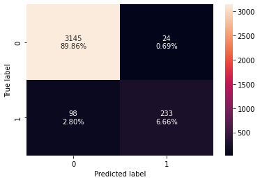

```python
# creating confusion matrix
confusion_matrix_sklearn_with_threshold(lg, X_train, y_train)
```

```python
log_reg_model_train_perf = model_performance_classification_sklearn_with_threshold(
    lg, X_train, y_train
)

print("Training performance:")
log_reg_model_train_perf
```

```
Training performance:
```

|  | Accuracy | Recall | Precision | F1 |
| --- | --- | --- | --- | --- |
| 0 | 0.965143 | 0.703927 | 0.906615 | 0.792517 |

#### Checking performance on test set

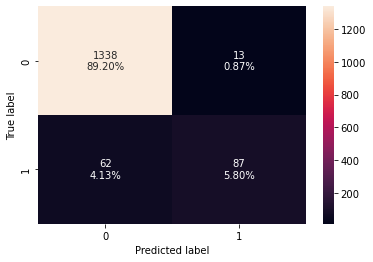

```python
# creating confusion matrix
confusion_matrix_sklearn_with_threshold(lg, X_test, y_test)
```

```python
log_reg_model_test_perf = model_performance_classification_sklearn_with_threshold(
    lg, X_test, y_test
)

print("Test set performance:")
log_reg_model_test_perf
```

```
Test set performance:
```

|  | Accuracy | Recall | Precision | F1 |
| --- | --- | --- | --- | --- |
| 0 | 0.95 | 0.583893 | 0.87 | 0.698795 |

#### ROC-AUC

- ROC-AUC on training set

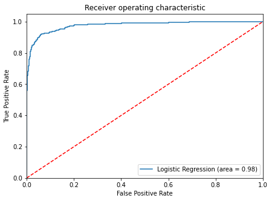

```python
logit_roc_auc_train = roc_auc_score(y_train, lg.predict_proba(X_train)[:, 1])
fpr, tpr, thresholds = roc_curve(y_train, lg.predict_proba(X_train)[:, 1])
plt.figure(figsize=(7, 5))
plt.plot(fpr, tpr, label="Logistic Regression (area = %0.2f)" % logit_roc_auc_train)
plt.plot([0, 1], [0, 1], "r--")
plt.xlim([0.0, 1.0])
plt.ylim([0.0, 1.05])
plt.xlabel("False Positive Rate")
plt.ylabel("True Positive Rate")
plt.title("Receiver operating characteristic")
plt.legend(loc="lower right")
plt.show()
```

- ROC-AUC on test set

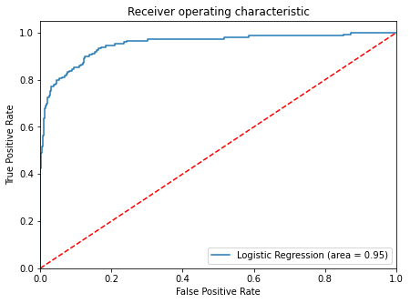

```python
logit_roc_auc_test = roc_auc_score(y_test, lg.predict_proba(X_test)[:, 1])
fpr, tpr, thresholds = roc_curve(y_test, lg.predict_proba(X_test)[:, 1])
plt.figure(figsize=(7, 5))
plt.plot(fpr, tpr, label="Logistic Regression (area = %0.2f)" % logit_roc_auc_test)
plt.plot([0, 1], [0, 1], "r--")
plt.xlim([0.0, 1.0])
plt.ylim([0.0, 1.05])
plt.xlabel("False Positive Rate")
plt.ylabel("True Positive Rate")
plt.title("Receiver operating characteristic")
plt.legend(loc="lower right")
plt.show()
```

- Model is giving a generalized performance.

### Model Performance Improvement

- Let's see if the f1 score can be improved further, by changing the model threshold using AUC-ROC Curve.

### Optimal threshold using AUC-ROC curve

```python
# Optimal threshold as per AUC-ROC curve
# The optimal cut off would be where tpr is high and fpr is low
fpr, tpr, thresholds = roc_curve(y_train, lg.predict_proba(X_train)[:, 1])

optimal_idx = np.argmax(tpr - fpr)
optimal_threshold_auc_roc = thresholds[optimal_idx]
print(optimal_threshold_auc_roc)
```

```
0.13634925366365924
```

#### Checking model performance on training set

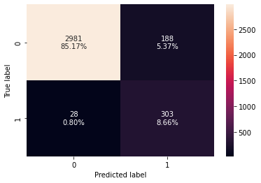

```python
# creating confusion matrix
confusion_matrix_sklearn_with_threshold(
    lg, X_train, y_train, threshold=optimal_threshold_auc_roc
)
```

```python
# checking model performance for this model
log_reg_model_train_perf_threshold_auc_roc = model_performance_classification_sklearn_with_threshold(
    lg, X_train, y_train, threshold=optimal_threshold_auc_roc
)
print("Training performance:")
log_reg_model_train_perf_threshold_auc_roc
```

```
Training performance:
```

|  | Accuracy | Recall | Precision | F1 |
| --- | --- | --- | --- | --- |
| 0 | 0.938286 | 0.915408 | 0.617108 | 0.737226 |

#### Checking model performance on test set

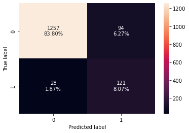

```python
# creating confusion matrix
confusion_matrix_sklearn_with_threshold(
    lg, X_test, y_test, threshold=optimal_threshold_auc_roc
)
```

```python
# checking model performance for this model
log_reg_model_test_perf_threshold_auc_roc = model_performance_classification_sklearn_with_threshold(
    lg, X_test, y_test, threshold=optimal_threshold_auc_roc
)
print("Test set performance:")
log_reg_model_test_perf_threshold_auc_roc
```

```
Test set performance:
```

|  | Accuracy | Recall | Precision | F1 |
| --- | --- | --- | --- | --- |
| 0 | 0.918667 | 0.812081 | 0.562791 | 0.664835 |

- The Recall of the model for both training and test set has improved but the precision score has reduced.

#### Let's use Precision-Recall curve and see if we can find a better threshold

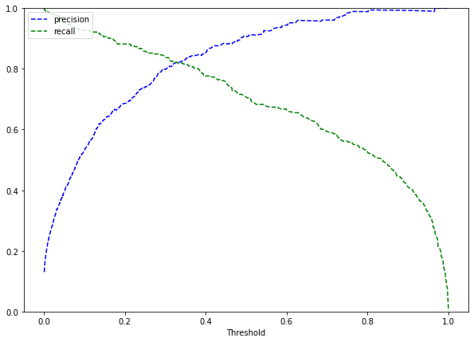

```python
y_scores = lg.predict_proba(X_train)[:, 1]
prec, rec, tre = precision_recall_curve(y_train, y_scores,)


def plot_prec_recall_vs_tresh(precisions, recalls, thresholds):
    plt.plot(thresholds, precisions[:-1], "b--", label="precision")
    plt.plot(thresholds, recalls[:-1], "g--", label="recall")
    plt.xlabel("Threshold")
    plt.legend(loc="upper left")
    plt.ylim([0, 1])


plt.figure(figsize=(10, 7))
plot_prec_recall_vs_tresh(prec, rec, tre)
plt.show()
```

- At the threshold of 0.35, we get balanced recall and precision.

```python
# setting the threshold
optimal_threshold_curve = 0.35
```

#### Checking model performance on training set

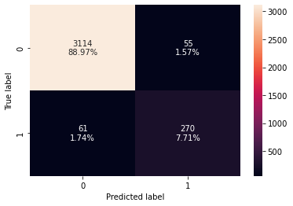

```python
# creating confusion matrix
confusion_matrix_sklearn_with_threshold(
    lg, X_train, y_train, threshold=optimal_threshold_curve
)
```

```python
log_reg_model_train_perf_threshold_curve = model_performance_classification_sklearn_with_threshold(
    lg, X_train, y_train, threshold=optimal_threshold_curve
)
print("Training performance:")
log_reg_model_train_perf_threshold_curve
```

```
Training performance:
```

|  | Accuracy | Recall | Precision | F1 |
| --- | --- | --- | --- | --- |
| 0 | 0.966857 | 0.81571 | 0.830769 | 0.823171 |

#### Checking model performance on test set

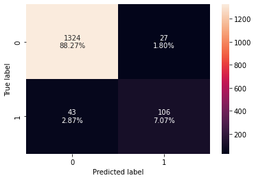

```python
# creating confusion matrix
confusion_matrix_sklearn_with_threshold(
    lg, X_test, y_test, threshold=optimal_threshold_curve
)
```

```python
log_reg_model_test_perf_threshold_curve = model_performance_classification_sklearn_with_threshold(
    lg, X_test, y_test, threshold=optimal_threshold_curve
)
print("Test set performance:")
log_reg_model_test_perf_threshold_curve
```

```
Test set performance:
```

|  | Accuracy | Recall | Precision | F1 |
| --- | --- | --- | --- | --- |
| 0 | 0.953333 | 0.711409 | 0.796992 | 0.751773 |

- Model is performing well on training and test.
- There's improvement in the model performance as the default threshold is 0.50 and here we get 0.35 as the optimal threshold.

### Model Performance Summary

```python
# training performance comparison

models_train_comp_df = pd.concat(
    [
        log_reg_model_train_perf.T,
        log_reg_model_train_perf_threshold_auc_roc.T,
        log_reg_model_train_perf_threshold_curve.T
    ],
    axis=1,
)
models_train_comp_df.columns = [
    "Logistic Regression sklearn",
    "Logistic Regression-0.14 Threshold",
    "Logistic Regression-0.35 Threshold"
]
print("Training performance comparison:")
models_train_comp_df
```

```
Training performance comparison:
```

|  | Logistic Regression sklearn | Logistic Regression-0.14 Threshold | Logistic Regression-0.35 Threshold |
| --- | --- | --- | --- |
| Accuracy | 0.965143 | 0.938286 | 0.966857 |
| Recall | 0.703927 | 0.915408 | 0.815710 |
| Precision | 0.906615 | 0.617108 | 0.830769 |
| F1 | 0.792517 | 0.737226 | 0.823171 |

```python
# testing performance comparison

models_test_comp_df = pd.concat(
    [
        log_reg_model_test_perf.T,
        log_reg_model_test_perf_threshold_auc_roc.T,
        log_reg_model_test_perf_threshold_curve.T
        ],
    axis=1,
)
models_test_comp_df.columns = [
    "Logistic Regression sklearn",
    "Logistic Regression-0.14 Threshold",
    "Logistic Regression-0.35 Threshold"
]
print("Test set performance comparison:")
models_test_comp_df
```

```
Test set performance comparison:
```

|  | Logistic Regression sklearn | Logistic Regression-0.14 Threshold | Logistic Regression-0.35 Threshold |
| --- | --- | --- | --- |
| Accuracy | 0.950000 | 0.918667 | 0.953333 |
| Recall | 0.583893 | 0.812081 | 0.711409 |
| Precision | 0.870000 | 0.562791 | 0.796992 |
| F1 | 0.698795 | 0.664835 | 0.751773 |

- The Model performed best on the balanced threshold for Training and Test Data

## Important Feature selection

### How sequential feature selector works?

- It starts with an empty model and adds in variables one by one.
- In each forward step, you add the one variable that gives the highest improvement to your model.

```python
# Sequential feature selector is present in mlxtend library
# !pip install mlxtend to install mlxtent library

from mlxtend.feature_selection import SequentialFeatureSelector as SFS

# to plot the performance with addition of each feature
from mlxtend.plotting import plot_sequential_feature_selection as plot_sfs
```

```python
# from sklearn.linear_model import LogisticRegression

# Fit the model on train
model = LogisticRegression(solver="newton-cg", n_jobs=-1, random_state=1, max_iter=100)
```

```python
# we will first build model with all varaible
sfs = SFS(
    model,
    k_features=len(X.columns.tolist()),
    forward=True,
    floating=False,
    scoring="f1",
    verbose=2,
    cv=3,
    n_jobs=-1,
)

sfs = sfs.fit(X_train, y_train)
```

[output not shown]

[output cut: 573 more lines]

[output not shown]

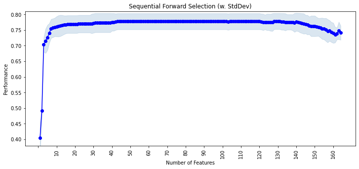

```python
fig1 = plot_sfs(sfs.get_metric_dict(), kind="std_dev", figsize=(12, 5))
x_ticks = np.arange(0, 164, 10)
plt.xticks(x_ticks)
plt.ylim([0.38, 0.81])
plt.title("Sequential Forward Selection (w. StdDev)")
plt.xticks(rotation=90)
plt.show()
```

[output not shown]

[output cut: 142 more lines]

[output not shown]

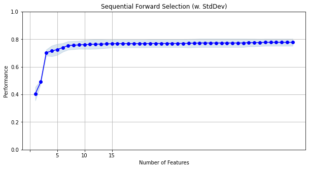

```python
sfs1 = SFS(
    model,
    k_features=48,
    forward=True,
    floating=False,
    scoring="f1",
    verbose=2,
    cv=3,
    n_jobs=-1,
)

sfs1 = sfs1.fit(X_train, y_train)

fig1 = plot_sfs(sfs1.get_metric_dict(), kind="std_dev", figsize=(10, 5))

x_ticks = np.arange(0, 16, 5)
plt.xticks(x_ticks)
plt.ylim([0, 1])
plt.title("Sequential Forward Selection (w. StdDev)")
plt.grid()
plt.show()
```

**Finding which features are important?**

```python
feat_cols = list(sfs1.k_feature_idx_)
print(feat_cols)
```

```
[1, 5, 7, 9, 10, 11, 12, 14, 15, 18, 19, 20, 22, 24, 25, 26, 27, 29, 31, 33, 35, 36, 37, 40, 41, 43, 44, 48, 50, 51, 52, 54, 57, 58, 60, 62, 63, 64, 66, 69, 70, 77, 81, 87, 89, 102, 116, 133]
```

**Let's look at best 48 variables**

```python
X_train.columns[feat_cols]
```

```
Index(['Income', 'CD_Account', 'CreditCard', 'Family_3', 'Family_4',
       'Education_2', 'Education_3', 'Zip_Section_03', 'Zip_Section_04',
       'Zip_Section_07', 'Zip_Section_08', 'Zip_Section_10', 'Zip_Section_12',
       'Zip_Section_14', 'Zip_Section_16', 'Zip_Section_17', 'Zip_Section_18',
       'Zip_Section_20', 'Zip_Section_22', 'Zip_Section_24', 'Zip_Section_26',
       'Zip_Section_27', 'Zip_Section_28', 'Zip_Section_33', 'Zip_Section_34',
       'Zip_Section_36', 'Zip_Section_37', 'Zip_Section_42', 'Zip_Section_44',
       'Zip_Section_45', 'Zip_Section_46', 'Zip_Section_48', 'Zip_Section_51',
       'Zip_Section_52', 'Zip_Section_54', 'Zip_Section_56', 'Zip_Section_57',
       'Zip_Section_58', 'Zip_Section_60', 'Zip_Area_02', 'Zip_Area_03',
       'Zip_Area_10', 'Zip_Area_14', 'Zip_Area_20', 'Zip_Area_22',
       'Zip_Area_35', 'Zip_Area_49', 'Zip_Area_66'],
      dtype='object')
```

- It is very obvious that the Location and Area of the Customer played a very important role in the model

```python
X_train_final = X_train[X_train.columns[feat_cols]]

# Creating new x_test with the same variables that we selected for x_train
X_test_final = X_test[X_train_final.columns]
```

```python
# Fitting logistic regession model

logreg = LogisticRegression(
    solver="newton-cg", penalty="none", verbose=True, n_jobs=-1, random_state=0
)

# There are several optimizer, we are using optimizer called as 'newton-cg' with max_iter equal to 10000
# max_iter indicates number of iteration needed to converge

logreg.fit(X_train_final, y_train)
```

```
[Parallel(n_jobs=-1)]: Using backend LokyBackend with 4 concurrent workers.
[Parallel(n_jobs=-1)]: Done   1 out of   1 | elapsed:    2.1s finished
```

```
LogisticRegression(n_jobs=-1, penalty='none', random_state=0,
                   solver='newton-cg', verbose=True)
```